# A3: SPL Library Checkouts

### Introduction

In this analysis, I use the data that records items checked out at least 10 times a month from 2017-2022 from the Seattle Public Library. I want to see the trend of total checkout numbers for digital items and physical items over the years, the average checkout number for the top 3 popular material types over time in 2022, and how each checkout type contributes to each year’s total checkout number. By looking at these patterns, we can have a better idea of how users reading preference change over time in the Seattle Public Library, and if there is any unusual pattern that can allow us to further investigation of its potential cause.

### The Dataset

- Who collected/published the data?
  - The data is published and updated monthly by The Seattle Public Library.
- What are the parameters of the data (dates, number of checkouts, kinds of books, etc.)?
  - There are 12 columns in the dataset: the form (digital/physical) of the item, the tool used to checkout, the type of item checked out, year and month of checkout, number of times the title was checked out within a month, and the title, ISBNs, author, subject, publisher, and publication year of the item. For my analysis, I will only use the data between 2017 to 2022 because the data for 2023 is too little to use. I will only use the data that was recorded for the whole year.
- How was the data collected or generated?
  - The data was collected and generated by The Seattle Public Library as they checkout items.
- Why was the data collected?
  - The data was collected to not only store the record of checkout but also to provide data for others to analyze the pattern and trend of item popularity.
- What, if any, ethical questions do you need to consider when working with this data?
  - Since I don’t see any personal information about the people who check out the item, I think the ethical problem for user privacy is not that serious. However, the library user might not be aware that the library is collecting this checkout data. For further analysis, we, or the library, should consider asking for users’ consent for the public to see and use the data without ethical issue.
- What are possible limitations or problems with this data? (at least 200 words)
  - As I look into the dataset, the syntax of the value of each column varies. For example, for the publication year, there are data values like “2022”, “[2022]”, or “2022,”. It will need extra data cleaning in order to process and analyze the data without getting into errors or problems. And for columns like item title, creator, subjects, and publisher, the value is unique since there are so many different items. Unlike checkout year, we can hardly find patterns with these columns. Therefore, we should carefully select the columns or variables that we want to analyze. Additionally, the data has a wide time range, and the data can be affected by some events that happened in these timeframes. For example, some influential events like COVID, new technology released, or events happening in the Seattle area can affect the data. Thus we can analyze or categorize the data based on these events. By doing so, we should also include information about these possible influential factors and explain how the situation would affect the data. Also, the data are only collected in the Seattle Public Library, so it cannot represent its result to the whole Seattle area. It can only tell the situation in its own library.

### First Trends Over Time Chart

- Chart:
  - Line Plot
- Question:
  - What is the trend in total checkouts for digital and physical items over the years?
- Description:
  - This line plot shows the trend of the total checkouts for digital and physical items between 2017 and 2022. Before the mid-year of 2019, the number of checkouts for physical items is much greater than that for digital items even though the checkout number was decreasing for physical items and increasing for digital items over time. Starting from the beginning of 2019 to 2020, the checkout number for physical items dropped so significantly that it became much less than for digital items. After 2020, the checkout number for both item types increases, and the checkout number for Physical items overall increases more than that for digital items. In short, the overall trend of digital item checkouts is increasing, and the overall trend of physical item checkouts is decreasing. This chart is included to find the changes in people’s reading habits over time. And by looking at its pattern, we can further investigate what happened in a specific timeframe that causes some unusual changes in the chart, like the sharp drop between 2019 to 2020 for physical items.

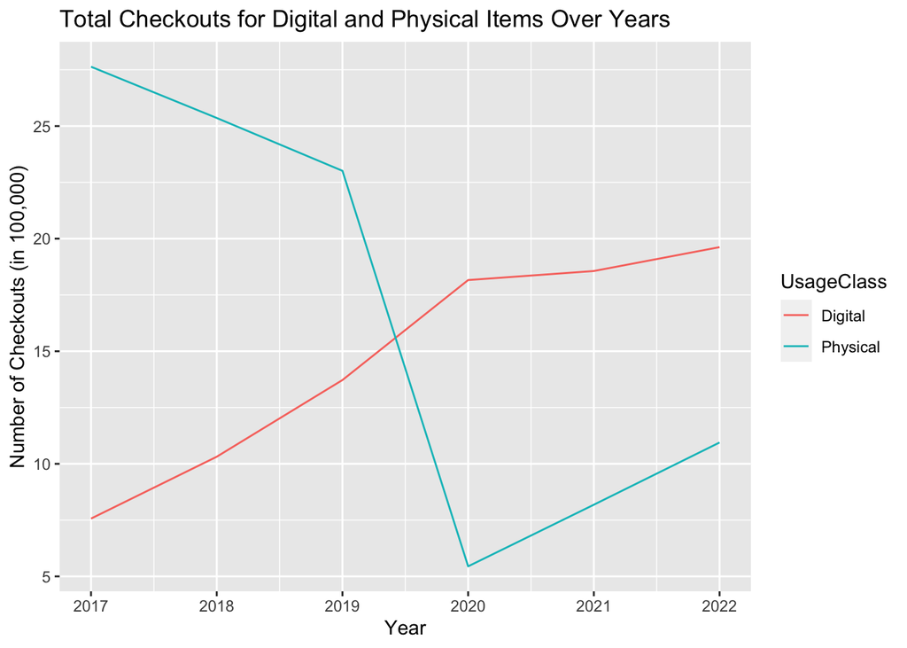

### Second Trends Over Time Chart

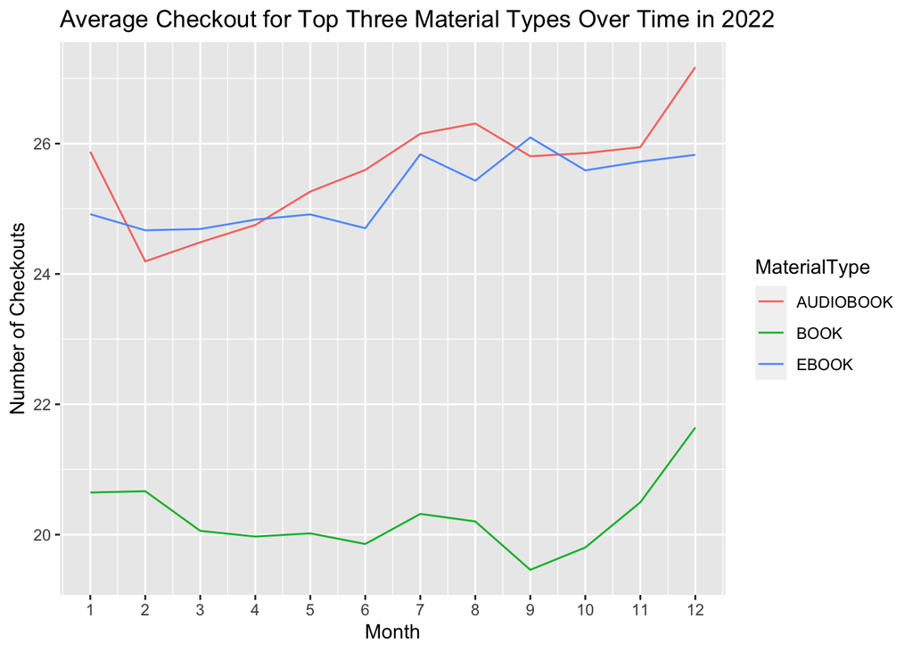

### Your Choice

- Chart:
  - Bar Plot
- Question:
  - On average, which year has the highest checkout numbers? How has the main checkout type changed?
- Description:
  - This bar chart shows the total checkout numbers per year and how each checkout type contributes to these numbers. There are 5 types of checkout vendor tools, and we can see the most dominant types are Horizon and OverDrive. Between 2017 to 2019, the number of checkouts by Horizon greatly outweighs other types, which are more than 50%. And the total checkout number over the years increases slightly as well. The total number peeks in 2019 but dropped greatly in 2020, which reaches the lowest number in all years. Between 2020 to 2022, the checkout number by OverDrive greatly outweighs Horizon, which is more than 50%. And we can barely see other types in these years. The total checkout number per year increases as well. But the overall number between 2020 to 2022 is less than that between 2017 to 2019. This chart is included to see how people’s main checkout tools and total checkout numbers change over time. Since Horizon is used for physical items checkout and OverDrive for digital items, we can then make a conclusion that the main checkout item type is physical between 2017 to 2019 is physical and digital between 2020 to 2022.

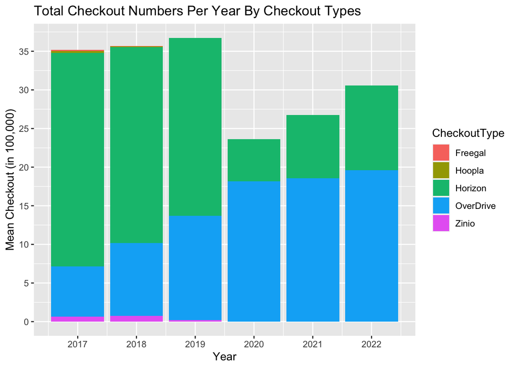